# Bruhn_B01_2

## B1.10 材料の挙動とその特性

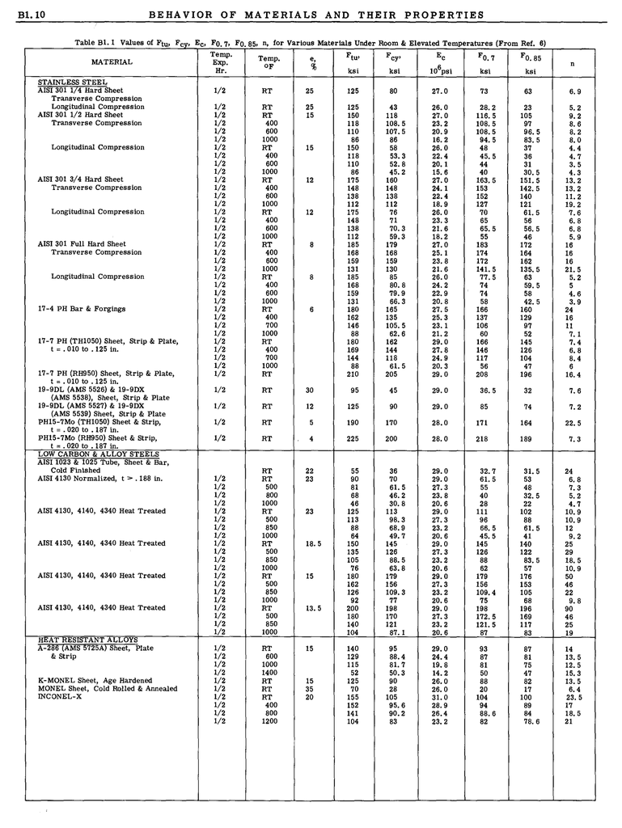

Table B1.1

## B1.11

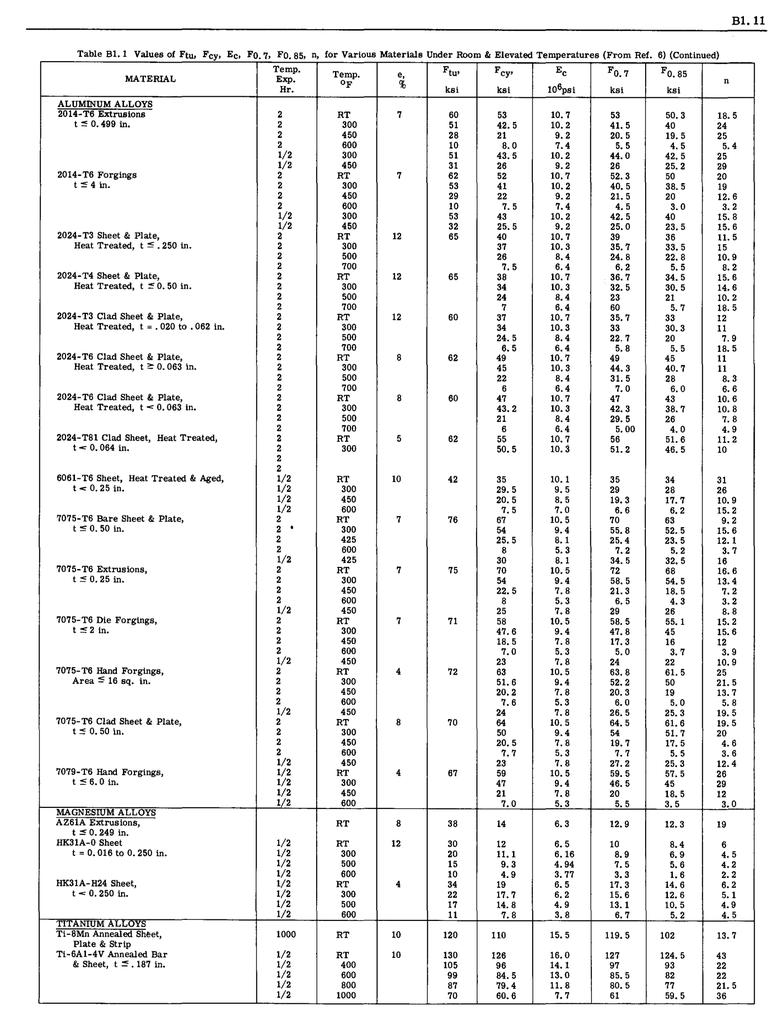

Table B1.1 (Continued)

## B1.12 材料の挙動とその特性

図 B1.15（曲線 A および B）は、ある材料の応力-ひずみ曲線を示している。曲線（A）は低い高温状態におけるものであり、曲線（B）は高い高温状態におけるものである。これらの結果は、短時間の試験期間を要する通常の試験機手順によって得られたものであるため、時間の影響を受けないものとみなすことができる。

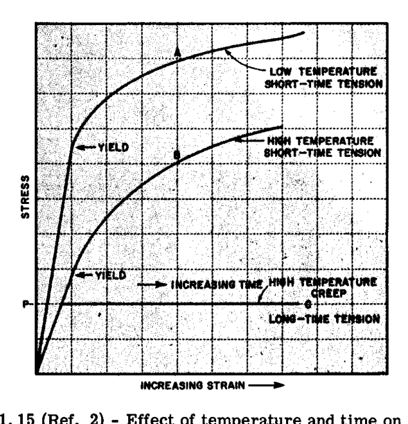

図 B1.15

**図 B1.15 (文献 2) - 金属の強度特性に対する温度および時間の影響**

この図は、より高い温度（曲線 B）が、より低い温度での試験である曲線（A）と比較して、材料の引張強さ、降伏強さ、および弾性係数を低下させることを示している。

### 時間の影響

温度と応力の組み合わせが、無視できないクリープを生じるようなものである場合、時間は重要な影響因子となる。例えば、図 B1.15 において、低温下の材料（曲線 A）に材料の弾性限度内の値 $P$ の応力を加え、この応力をかなりの時間維持した場合、クリープはほとんど検出されず、応力を取り除くと材料は実質的に元の寸法に戻る。しかし、材料に同じ値 $P$ の応力を加えても、高温状態であれば、応力 $P$ が加えられている限りクリープが発生し、応力-ひずみ曲線は図 B1.15 の曲線（C）のような形状をとる。この時間依存のひずみは、特徴的なパターンをたどる。クリープが発生した後は、応力を取り除いたとしても、材料が元の形状に戻ることは決してない。応力と高温の両方が継続すると、最終的にはクリープによる破断が発生する。

### B1.15 一般的なクリープパターン

クリープ破断試験データの代表的なプロット方法を 図 B1.16 に示す。高い応力または温度の値で試験された金属では、図 B1.16 に示すように、クリープと時間の関係において3つの段階が観察される。第1段階（遷移クリープ段階とも呼ばれる）は、弾性変形と、時間の経過とともにクリープ変形速度がかなり急速に減少する領域を含んでおり、これは間違いなく加工硬化の影響を示している。第2段階（定常クリープ段階としばしば呼ばれる）は、かなりの期間にわたってひずみ速度が（高い応力を除いて）一定値まで減少した段階を表し、この段階は最小クリープ速度の期間を表す。第3段階（加速クリープ段階とも呼ばれる）は、断面積の減少がより高い応力、より大きなクリープ速度をもたらし、最終的に破断に至る期間を表す。

**遷移点。** 第2段階の一定クリープ速度と第3段階の増加する速度との間の変曲点は、遷移点と呼ばれる。破壊は一般に遷移点の後、比較的短時間で発生する。遷移点は非常に低い応力では発生しないことがあり、また非常に高い応力では定義できないこともある。最小クリープ速度は、クリープ速度が実質的に一定である第2段階において示されるものである。

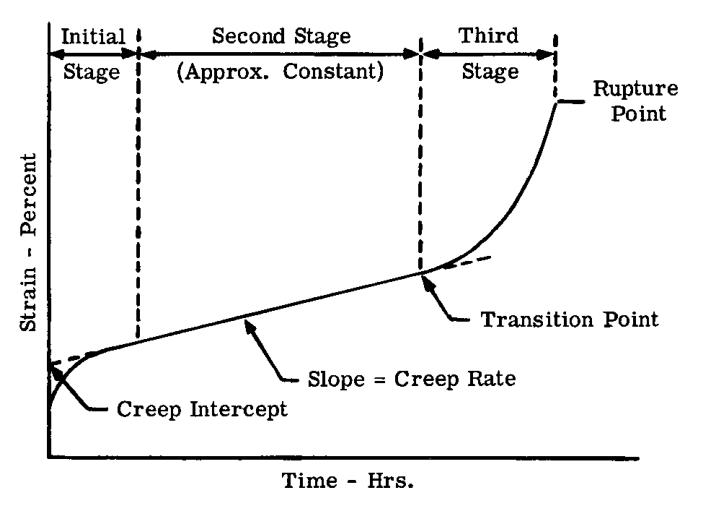

図 B1.16

**図 B1.16 代表的なクリープ破断曲線**

図 B1.17 は、一定温度かついくつかの応力レベルにおける材料のクリープ-時間曲線のプロットを示している。応力が増加すると、クリープと時間の関係が大きく変化することがわかる。

### B1.16 応力-時間設計チャート

動力プラントなど、高温を伴う多くの構造設計問題において、重要な設計因子は強度ではなく、構造物や機械が満足に機能または動作することを依然として許容できる許容クリープ量である。信頼性の高いクリープ設計情報を提供するためには通常、広範な試験が必要であり、そのような試験情報は図 B1.18 に示すような形式で記録されることが多い。

## B1.13

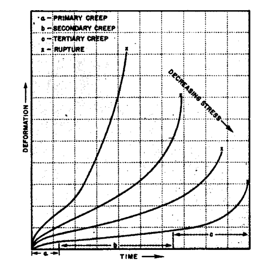

図 B1.17

**図 B1.17 (文献 2) 一定温度および様々な応力レベルにおける材料のクリープ曲線（クリープ挙動の特徴的な段階を示す）**

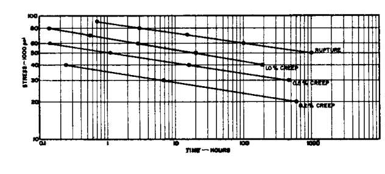

図 B1.18

**図 B1.18 (文献 2) - 限界応力値を選択するための単一の一定温度における応力-時間設計チャート**

### B1.17 暴露時間の影響

一般に材料は、高温への暴露時間が機械的特性に大きな影響を与えるものと、そのような暴露が比較的わずかな影響しか及ぼさないものに大別できる。

この一般的な事実は、図 B1.19 および図 B1.20 に示されている。図 B1.19 のアルミニウム合金の降伏強さは、図 B1.20 に示す鋼合金よりも、高温への暴露時間によってはるかに大きな影響を受ける。

### B1.18 急速加熱速度の影響

超音速航空機やミサイルは、急速な空気力学的加熱にさらされる。試験結果は、一般に金属が、一定温度下で1/2時間以上さらされた後に荷重を加えられた場合と比較して、一定荷重条件下で毎秒ゼロから $200^\circ\text{F}$ まで加熱された場合、特定の温度において実質的に高い応力に耐えられることを示している。加熱速度を毎秒 $200^\circ\text{F}$ から $2000^\circ\text{F}$ 以上に増加させても、強度のわずかな増加をもたらすだけである。図 B1.21 および図 B1.22 (文献 4) は、降伏強度および引張強さに対する毎秒最大 $100^\circ\text{F}$ までの加熱速度の影響を示している。

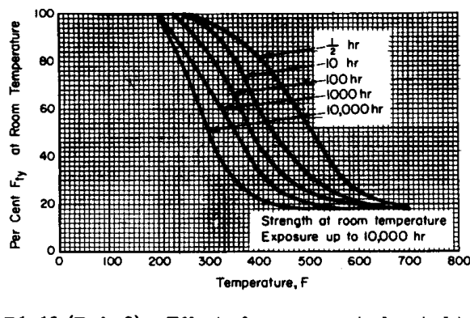

図 B1.19

**図 B1.19 (文献 3) - 7079-T6 アルミニウム合金（手鍛造品）の室温引張降伏強度（ $F_{ty}$ ）に対する高温暴露の影響**

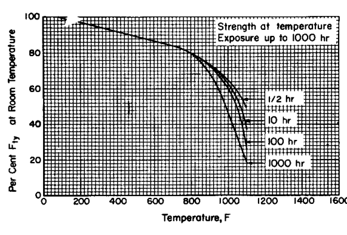

図 B1.20

**図 B1.20 (文献 3) - 5 Cr-Mo-V 航空機用鋼の引張降伏強度（ $F_{ty}$ ）に対する温度の影響**

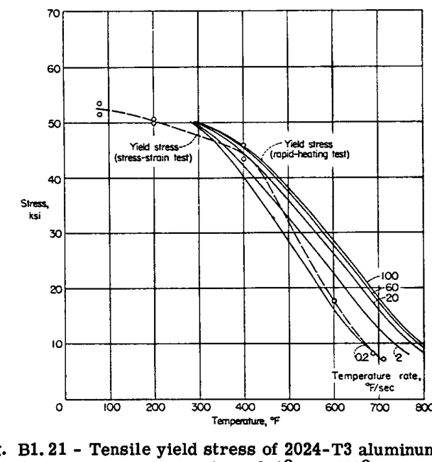

図 B1.21

**図 B1.21 - 加熱速度毎秒 $0.2^\circ\text{F}$ から $100^\circ\text{F}$ における 2024-T3 アルミニウム合金の引張降伏強度、および1/2時間暴露の応力-ひずみ試験結果**

## B1.14 材料の挙動とその特性

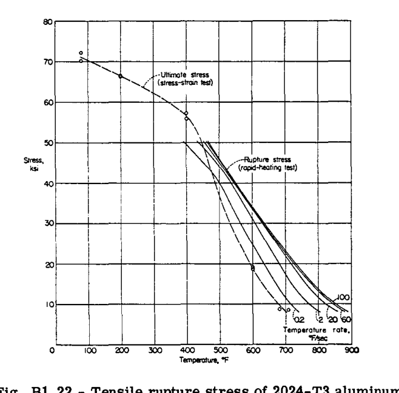

図 B1.22

**図 B1.22 - 加熱速度毎秒 $0.2^\circ\text{F}$ から $100^\circ\text{F}$ における 2024-T3 アルミニウム合金の引張破断応力、および1/2時間暴露の応力-ひずみ試験による引張強さ**

アルミニウム合金の強度は、一定温度に1/2時間さらされた後に荷重を加えられた場合の値と比較される。

### B1.20 材料の疲労

疲労破壊と呼ばれるものに対する安全性を確保するために構造を設計することは、飛行体の構造設計者が直面する最も重要かつ困難な問題の一つである。疲労破壊とは、多数回にわたって応力を受けることによる破壊である。例えば、梁は設計静荷重を安全かつ効率的に支持するように設計でき、この静荷重を破壊することなく無期限に支持する。しかし、この荷重が十分に多数回繰り返されると、この設計静荷重下で破壊する。静荷重下の梁の応力が高いほど、破壊に至るまでの繰返し回数は少なくなる。

現在までに、材料の疲労破壊を明確に説明するための十分な理論は開発されていない。疲労破壊は、材料の欠陥のある箇所から亀裂が始まり、結晶粒界に沿って進行することから始まるようである。金属の微視的な検査は、材料全体に多くの微小な亀裂が散在していることを示している。繰り返される応力の作用下で、これらの微小な亀裂は応力サイクルの間に開閉する。亀裂が存在しない場合の応力と比較して、亀裂の底部にはより高い応力が存在する。この繰り返される応力集中下で、亀裂は部材の断面を徐々に横切って広がり、最終的に部材の完全な破壊を引き起こす。

疲労試験は、以下の3つのタイプから構成される。 (1) 材料結晶の試験、(2) 小さな構造試験片の試験、および (3) 完全な複合構造の試験。2番目のタイプの試験については、膨大な量の試験情報が利用可能である。3番目のタイプの試験に、ますます多くの関心が払われている。例えば、航空機の安全な設計寿命を保証するために、完成した飛行機の翼や胴体は、しばしば入念な疲労試験にさらされる。

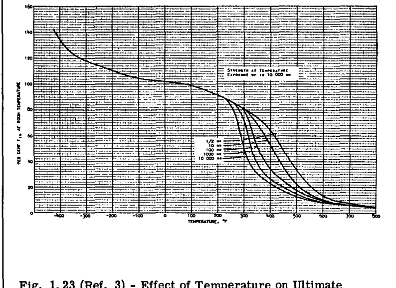

図 B1.23

**図 1.23 (文献 3) - 2014-T6 アルミニウム合金の引張強さ（ $F_{tu}$ ）に対する温度の影響**

## B1.15

初期の亀裂の存在は、疲労や進行性破壊を開始するために必ずしも必要ではない。スラグ介在物、表面の傷、ピッティングなどの不規則性は、腐食作用を開始させ、それによって亀裂の促進および結果としての進行性破壊の条件を提供し得るからである。

繰り返される応力下での鉄金属の強度は、しばしば耐久限度または疲労限度と呼ばれる。耐久限度応力は、材料の破壊を引き起こすことなく無限に繰り返すことができる応力である。アルミニウム合金などの非鉄材料は、上記で定義されたような耐久限度を持たず、応力サイクルが増加するにつれて弱まり続ける。この事実により、また構造物や機械の要求される耐用年数が大きく異なるため、耐久限度の代わりに耐久強度または疲労強度として、繰り返される応力下の強度を指すのが一般的である。したがって、疲労強度は、構造ユニットの破壊を引き起こすことなく、指定された回数のサイクルに対して繰り返すことができる最大応力である。

引張、圧縮、曲げなどの繰り返される応力下で試験片を試験した結果は、図 B1.24 に示すように、しばしば S-N（応力対サイクル）線図と呼ばれる形式でプロットされる。

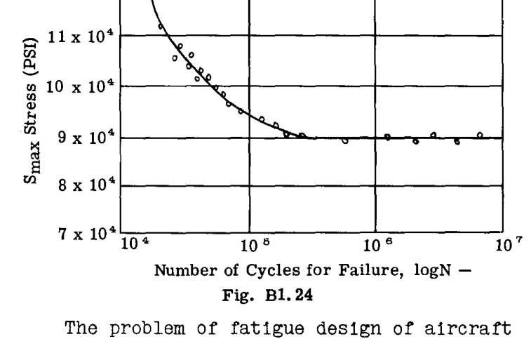

図 B1.24

**図 B1.24**

航空機機体の疲労設計の問題は、本書の第 C13 章で扱われている。

### B1.21 材料特性に対する衝撃荷重の影響

衝撃荷重が構造物に作用すると、無視できない衝撃または振動が発生する。そのような作用を生じさせるためには、荷重を急速に、すなわち短い時間間隔で加えなければならない。衝撃荷重の影響は静的荷重の影響とは異なり、衝撃荷重は部材に生じる応力の大きさに著しく影響を与え、また荷重下の材料の耐性特性や挙動にも影響を与える。航空機構造における動的荷重の重要性と影響については、第 A4 章で簡単に説明されている。以下に続く限定的な議論では、材料の挙動に対する衝撃荷重の影響のみを扱う。

### 衝撃試験方法

衝撃荷重下での材料の挙動を決定するための試験には、一般に2つのタイプがある。長年にわたって実施されてきた通常の衝撃試験は、切欠きバー試験と呼ばれ、切欠き試験片に、よく知られたシャルピーまたはアイゾット衝撃試験機によって軸方向、曲げ、およびねじり荷重を加えることからなる。これら両方の試験機において、衝撃荷重は、特定の垂直高さ（ $h$ ）からおもり $W$ を振って切欠き試験片に衝突させて破断させ、その後、垂直高さ（ $h'$ ）で停止させることによって試験片に加えられる。試験片を破断するのに消費されたエネルギーは、およそ $(Wh - Wh')$ に等しい。このタイプの試験は、主に冶金学的変数の影響を研究するために使用される。

もう一つのタイプの衝撃試験は、切欠きのない試験片に対して行われ、一般的な目的は、衝撃荷重下での材料の応力-ひずみ線図、または衝撃荷重下でユニットが完全に破壊されたときの構造部材もしくは複合構造の荷重-ひずみ線図を得ることである。

### B1.22 材料の衝撃試験のいくつかの結果の例

図 B1.25、26、および 27 は、静的な応力-ひずみ線図と比較した、応力-ひずみ曲線に対する衝撃試験の結果を示している（文献 5）。

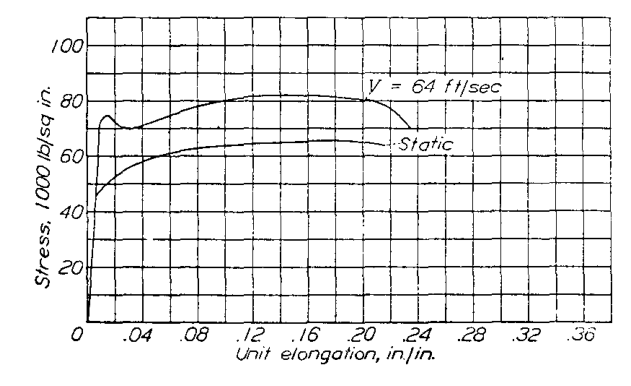

図 B1.25

**図 B1.25 - 応力-ひずみ曲線、24ST アルミニウム合金**

## B1.16 材料の挙動とその特性

表 B1.2 は、静的試験結果と比較した追加の衝撃試験結果を示している。

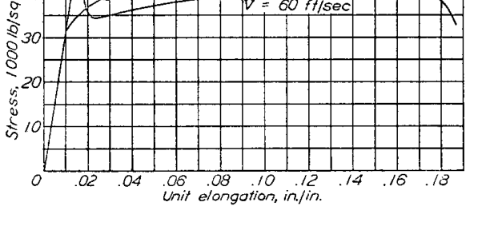

図 B1.26

**図 B1.26 - 応力-ひずみ曲線、ダウメタル X**

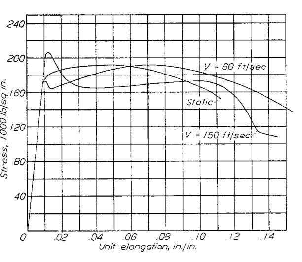

図 B1.27

**図 B1.27 - 応力-ひずみ曲線、SAE 6140、1020°F 焼き戻し**

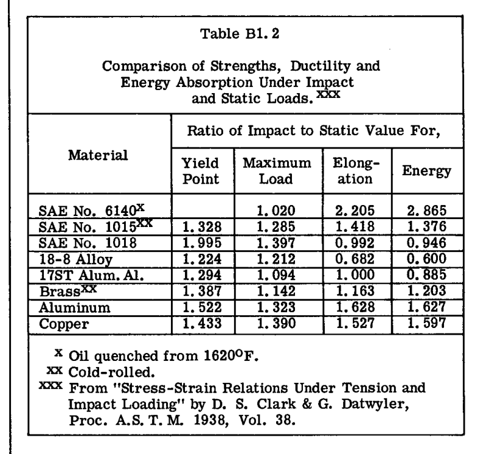

Table B1.2

### 参考文献

- **Ref. 1.** Ramberg & Osgood. “Description of Stress-Strain Curves of 3 Parameters.” NACA, Tech. Note 902.
- **Ref. 2.** “Time and Temperature Gremlins of Destruction.” By L. A. Yerkorvich, Cornell Aero. Lab. Research Trends. Sept. 1956.
- **Ref. 3.** “Military Handbook (MIL-HDBK-5)” Aug. 1962.
- **Ref. 4.** NACA Technical Note 3462.
- **Ref. 5.** NACA Technical Note 868.
- **Ref. 6.** From Structures Manual, Convair Astronautics.